# Lecture 10 - Lyapunov’s Indirect Method and Regions of Attraction

Published

February 12, 2026

Based on notes created by Sam Coogan and Murat Arcak. Licensed under a “Creative Commons Attribution-NonCommercial-ShareAlike 4.0 International License”

Additional Reading

- Khalil, Chapter 4.3-4.7, 8.2

Overview

- Further tools for studying systems based on their linearization
- Define region of attraction
- Obtain Lyapunov estimates of the region of attraction

In the last lecture, we introduced the Lyapunov equation[^1] and showed that it can be used to test whether or not a matrix $A$ is Hurtwitz, by defining some positive definite matrix $Q$ and solving the Lyapunov equation for $P$. Then, if the Lyapunov equation has a positive definite solution, we conclude that $A$ is Hurwitz.

<sup>1</sup> $PA + A^TP = -Q$

For linear systems, this method has no computational advantage over calculating the eigenvalues of $A$.

However, for nonlinear systems, we can establish that $V = x^TPx$ (derived using the linearized system) is locally a Lyapunov function for the nonlinear system.

## Lyapunov’s Indirect Method

Let’s go back to our nonlinear system:
$$\dot x = f(x), \quad f(0) = 0,$$
where $f: D \to \R^n$ is $C^1$ and $D \subset \R^n$ is a neighborhood of the equilibrium point $x=0$.

We can rewrite the nonlinear system to be in the form $\dot{x} = Ax + g(x)$ by leveraging the mean value theorem:
$$\begin{align*}
\frac{\partial f_i}{\partial x}(z_i) &= \frac{f_i(x) - f_i(0)}{x - 0}
\end{align*}$$
with $z_i$ being a point on the line segment connecting $0$ and $x$. This can be rearranged to get our desired form:
$$\begin{align*}
f_i(x) &= \cancel{f_i(0)} + \frac{\partial f_i}{\partial x}(z_i)x \\
&= \frac{\partial f_i}{\partial x}(0)x + \underbrace{\left[\frac{\partial f_i}{\partial x}(z_i) - \frac{\partial f_i}{\partial x}(0) \right]x}_{g_i(x)} \\
f(x) &= A x + g(x)
\end{align*}$$

The function $g_i(x)$ satisfies:
$$\begin{align*}
|g_i(x)| \leq \left\| \frac{\partial f_i}{\partial x}(z_i) - \frac{\partial f_i}{\partial x}(0) \right\| \|x\|
\end{align*}$$

By continuity of $[\partial f / \partial x]$, we see that
$$\begin{align*}
\frac{\|g(x)\|}{\|x \|} \to 0 \quad \text{as} \quad \|x\| \to 0
\end{align*}$$

This suggests that in a small neighborhood of the origin we can approximate the nonlinear system by its linearization about the origin.

We can formalize this conclusion in a Theorem that follows the same logic we’ve been using throughout the course (i.e., Linear Stability Theory and Hartman-Grobman Theorem). However, we can only now formalize and prove this theorem using Lyapunov’s Stability Theorem. Because the proof relies on Lyapunov functions, this approach is known as **Lyapunov’s indirect method**.

Let $x = 0$ be an equilibrium point for the nonlinear system $\dot{x} = f(x)$, where $f: D \to \R^n$ is $C^1$ and $D \subset \R^n$ is a neighborhood of the origin. Let
$$A = \left. \frac{\partial f(x)}{\partial x} \right|_{x=0}$$

Then,

- If $\Re\{\lambda_i(A)\} < 0$ for all eigenvalues of $A$, then the origin is asymptotically stable for the nonlinear system.
- If $\Re\{\lambda_i(A)\} > 0$ for some eigenvalue of $A$, then the origin is unstable for the nonlinear system.

**Note:** We can conclude only *local* asymptotic stability from this linearization. Inconclusive if $A$ has eigenvalues on the imaginary axis.

*Proof*. Find $P = P^T > 0$ such that $A^TP + PA = -Q < 0$. Use $V(x) = x^T P x$ as a Lyapunov function for the nonlinear system $\dot x = Ax + g(x)$.
$$\begin{align*}
\dot V(x) &= x^TP \dot{x} + \dot{x}^T P x \\
&= x^TP(Ax + g(x)) + (Ax + g(x))^TPx \\
&= x^T(PA+ A^T P)x + 2x^TPg(x) \\
&= -x^TQx + 2x^TPg(x) \\
\end{align*}$$

The second term is (in general) indefinite, but since we know that $\|g(x)\| / \|x\| \to 0$ as $x \to 0$, we can find a ball around the origin where the second term is negative definite. This is mathematically stated as: for any $\gamma > 0$, there exists $r > 0$ such that
$$\|g(x)\| < \gamma \|x\|, \quad \forall \|x\| < r$$
see the illustration below for the case $x \in \mathbb{R}$.

[figure not shown]

We can use this to bound our previous expression for $\dot{V}(x)$:
$$\begin{align*}
\dot{V}(x) &= -x^TQx + 2x^TPg(x) \\
&< -x^TQx + 2\gamma \|P\| \|x\|^2, \quad \forall \|x\| < r
% &\leq -x^TQx + 2\gamma \|P\| \|x\|^2
\end{align*}$$

This can be further bounded by observing the bounds on $x^TQx$:

$$\lambda_{\min}(Q) \|x\|^2 \le x^T Q x \le \lambda_{\max}(Q)\|x\|^2$$

Thus, plugging this bound into our expression:
$$\begin{align*}
\dot{V}(x) &< -\lambda_{\min}(Q) \|x\|^2 + 2\gamma \|P\| \|x\|^2 \\
&< -\left[ \lambda_{\min}(Q) - 2\gamma \|P\| \right] \|x\|^2
\end{align*}$$

Finally, we can choose $\gamma < \frac{\lambda_{\min}(Q)}{2\|P\|}$ so that $\dot{V}(x)$ is negative definite in a ball of radius $r(\gamma)$ around the origin. We can then appeal to Lyapunov’s Stability Theorem (previous lecture) to conclude (local) asymptotic stability.

## Region of Attraction

$$R_A = \{x : \phi(t, x) \to 0\}$$

“Quantifies” local asymptotic stability. Global asymptotic stability: $R_A = \R^n$.

If $x = 0$ is asymptotically stable, then its region of attraction is an open, connected, invariant set. Moreover, the boundary is formed by trajectories.

Example: van der Pol system in reverse time:
$$\begin{split}
\dot x_1 &= -x_2 \\
\dot x_2 &= x_1 - x_2 + x_2^3
\end{split}$$

The boundary is the (unstable) limit cycle. Trajectories starting within the limit cycle[^2] converge to the origin.

<sup>2</sup> A limit cycle is an isolated periodic orbit.

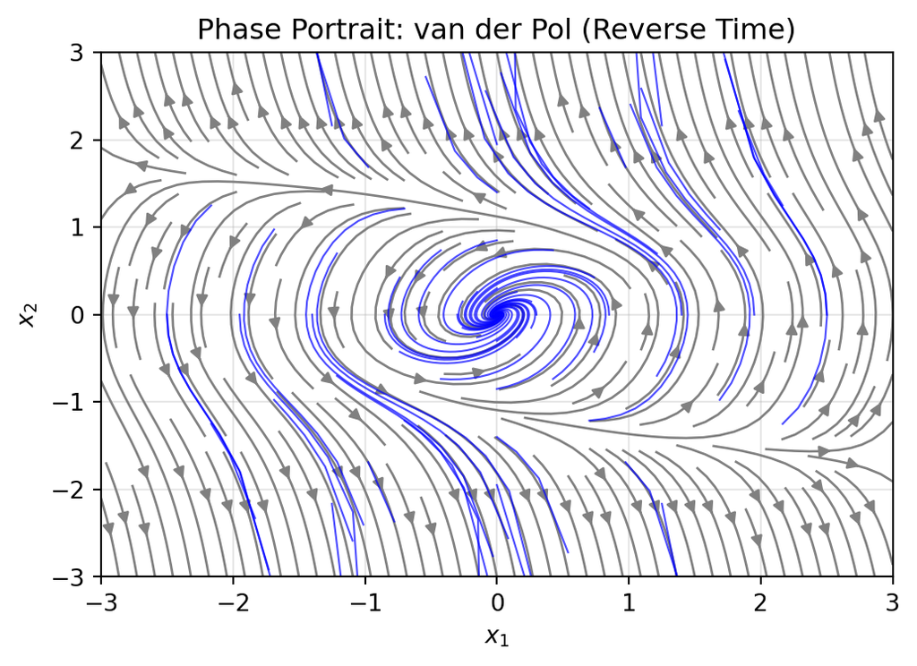

```python
import numpy as np
import matplotlib.pyplot as plt

# Define the system
def vdp_reverse(t, x):
  x1, x2 = x
  dx1 = -x2
  dx2 = x1 - x2 + x2**3
  return np.array([dx1, dx2])

# Create grid for vector field
x1 = np.linspace(-3, 3, 20)
x2 = np.linspace(-3, 3, 20)
X1, X2 = np.meshgrid(x1, x2)
U = -X2
V = X1 - X2 + X2**3

# Plot
fig, ax = plt.subplots(figsize=(6, 4))
ax.streamplot(X1, X2, U, V, color='gray', density=1.5, linewidth=1)

# Plot trajectories
from scipy.integrate import solve_ivp
max_time = 100
times = np.linspace(0, max_time, 1000)

# Generate a grid of initial conditions
initial_conditions = []
for r in np.linspace(0.3, 2.5, 5):
  for theta in np.linspace(0, 2*np.pi, 12, endpoint=False):
    x0 = r * np.array([np.cos(theta), np.sin(theta)])
    initial_conditions.append(x0)

# Integrate trajectories from all initial conditions
for x0 in initial_conditions:
  sol = solve_ivp(vdp_reverse, (0, max_time), x0, t_eval=times, dense_output=True)
  ax.plot(sol.y[0], sol.y[1], 'b-', linewidth=0.8, alpha=0.7)

ax.set_xlabel('$x_1$')
ax.set_ylabel('$x_2$')
ax.set_title('Phase Portrait: van der Pol (Reverse Time)')
ax.grid(True, alpha=0.3)
ax.set_xlim(-3, 3)
ax.set_ylim(-3, 3)
plt.show()
```

Example: bistable switch:
$$\begin{split}
\dot x_1 &= -ax_1 + x_2 \\
\dot x_2 &= \frac{x_1^2}{1 + x_1^2} - b x_2
\end{split}$$

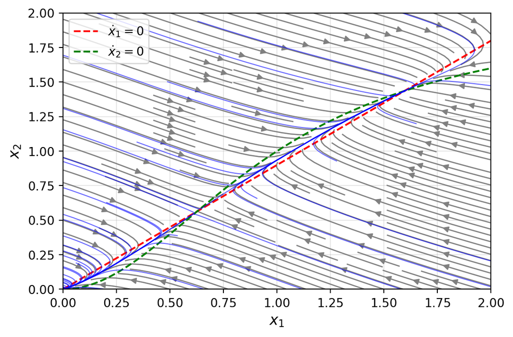

```python
# Parameters
a = 0.9
b = 0.5

# Define the bistable switch system
def bistable(t, x):
  x1, x2 = x
  dx1 = -a*x1 + x2
  dx2 = x1**2 / (1 + x1**2) - b*x2
  return np.array([dx1, dx2])

# Create vector field
x1 = np.linspace(0, 2, 25)
x2 = np.linspace(0, 2, 25)
X1, X2 = np.meshgrid(x1, x2)
U = -a*X1 + X2
V = X1**2 / (1 + X1**2) - b*X2

# Plot
fig, ax = plt.subplots(figsize=(6, 4))
ax.streamplot(X1, X2, U, V, color='gray', density=1.5, linewidth=1)

# Plot nullclines
x1_nullcline = np.linspace(0, 2, 100)
x2_nullcline = a * x1_nullcline
ax.plot(x1_nullcline, x2_nullcline, 'r--', label=r'$\dot{x}_1=0$')
x2_nullcline = (x1_nullcline**2 / (1 + x1_nullcline**2)) / b
ax.plot(x1_nullcline, x2_nullcline, 'g--', label=r'$\dot{x}_2=0$')
ax.legend(loc='upper left')

# Plot solution curves from multiple initial conditions
max_time = 50
times = np.linspace(0, max_time, 500)

for r in np.linspace(0.2, 2.5, 6):
  for theta in np.linspace(0, 2*np.pi, 10, endpoint=False):
    x0 = r * np.array([np.cos(theta), np.sin(theta)])
    sol = solve_ivp(bistable, (0, max_time), x0, t_eval=times, dense_output=True)
    ax.plot(sol.y[0], sol.y[1], 'b-', linewidth=0.8, alpha=0.6)

ax.set_xlabel('$x_1$', fontsize=12)
ax.set_ylabel('$x_2$', fontsize=12)
ax.grid(True, alpha=0.3)
ax.set_xlim(0, 2)
ax.set_ylim(0, 2)
plt.tight_layout()
plt.show()
```

## Estimating the Region of Attraction with a Lyapunov Function

Suppose $\dot V(x)< 0$ in $D - \{0\}$. The level sets of $V$ inside $D$ are invariant and trajectories starting in them converge to the origin. Therefore we can use the largest levet set of $V$ that fits into $D$ as an (under)approximation of the region of attraction.

[figure not shown]

This estimate depends on the choice of Lyapunov function. A simple (but often conservative) choice is: $V(x) = x^TPx$ where $P$ is selected for the linearization (see p.1).

### Example

Consider again the van der Pol system (a slightly different version for now):
$$\begin{align*}
\dot x_1 &= -x_2 \\
% \dot x_2 &= x_1 - x_2 + x_2^3
\dot x_2 &= x_1 + (x_1^2 - 1)x_2
\end{align*}$$

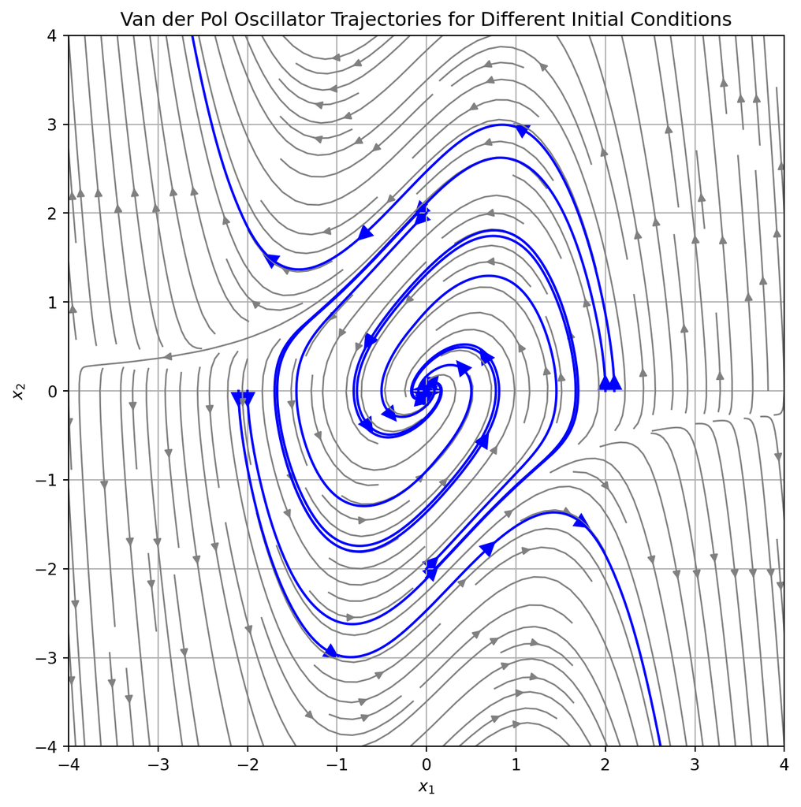

```python
import numpy as np
import matplotlib.pyplot as plt
from scipy.integrate import solve_ivp

# Define the Van der Pol oscillator
def van_der_pol_reverse(t, x, mu):
    dxdt = [-x[1], x[0] + mu*(x[0]**2 - 1) * x[1]]
    return dxdt

# Parameters
mu = 1.0
t_span = (0, 20)
dt = 0.01
# Initial conditions
initial_conditions = [[0, 2], [0, -2], [2, 0], [-2, 0]]
initial_conditions += [[2.1, 0], [-2.1, 0], [0, 2.1], [0, -2.1]]

# Create vector field
x1 = np.linspace(-4, 4, 20)
x2 = np.linspace(-4, 4, 20)
X1, X2 = np.meshgrid(x1, x2)
U = -X2
V = X1 + (X1**2 - 1) * X2

plt.figure(figsize=(8, 8))
plt.streamplot(X1, X2, U, V, color='gray', density=1.5, linewidth=1)

for ic in initial_conditions:
  sol = solve_ivp(van_der_pol_reverse, t_span, ic,
    t_eval=np.arange(t_span[0], t_span[1], dt),
    args=(mu,), dense_output=True)
  plt.plot(sol.y[0], sol.y[1], 'b-', linewidth=1.5)

  num_arrows = 5
  arrow_indices = np.linspace(0, len(sol.y[0]) - 2,
                num_arrows, dtype=int)
  for idx in arrow_indices:
    plt.arrow(sol.y[0][idx], sol.y[1][idx],
          sol.y[0][idx+1] - sol.y[0][idx],
          sol.y[1][idx+1] - sol.y[1][idx],
          head_width=0.15, head_length=0.15, fc='b', ec='b')

plt.xlabel(r'$x_1$')
plt.ylabel(r'$x_2$')
plt.title('Van der Pol Oscillator Trajectories for Different Initial Conditions')
plt.grid()
plt.xlim([-4, 4])
plt.ylim([-4, 4])
plt.show()
```

We will leverage our Lyapunov equation to find the region of attraction.

First, we linearize the system about the origin:
$$\begin{align*}
A = \left. \frac{\partial f(x)}{\partial x} \right|_{x=0} = \begin{bmatrix} 0 & -1 \\ 1 & -1 \end{bmatrix}
\end{align*}$$

We can observe that $A$ is Hurwitz, with eigenvalues $\lambda = -0.5 \pm 0.866i$. We can then find a $P$ such that $A^TP + PA = -Q$ where $Q$ is positive definite.

Selecting $Q = I$, the unique solution for $P$ (the solution to the Lyapunov equation $PA + A^TP = -I$) is:
$$\begin{align*}
P = \begin{bmatrix} 1.5 & -0.5 \\ -0.5 & 1 \end{bmatrix}
\end{align*}$$

Thus, the quadratic function $V(x) = x^TPx$ is a Lypaunov function for the system in a certain neighborhood of the origin.

Since we want to estimate the region of attraction, we need to find the largest level set of $V(x)$ that fits into the domain $D$ such that
$$\Omega_c = \{V(x) \leq c\}$$

First, checking our derivative condition:
$$\begin{align*}
\dot{V}(x) &= \dot{x}^TPx + x^TP\dot{x} \\
&= \begin{bmatrix}
-x_2 & x_1 + (x_1^2 - 1)x_2
\end{bmatrix}
\begin{bmatrix}
1.5 & -0.5 \\ -0.5 & 1
\end{bmatrix}
\begin{bmatrix}
x_1 \\ x_2
\end{bmatrix} \\
& \quad + \begin{bmatrix}
x_1 & x_2
\end{bmatrix}
\begin{bmatrix}
1.5 & -0.5 \\ -0.5 & 1
\end{bmatrix}
\begin{bmatrix}
-x_2 \\ x_1 + (x_1^2 - 1)x_2
\end{bmatrix} \\
&= 2(-1.5x_1x_2 + 0.5x_2^2 - 0.5x_1(x_1 + (x_1^2 - 1)x_2) + x_2(x_1 + (x_1^2 - 1)x_2)) \\
&= 2(0.5x_2^2 - 0.5x_1^2 -0.5x_1^3x_2 + x_2^2x_1^2) \\
&= -(x_1^2 + x_2^2) - (x_1^3x_2 - 2x_1^2x_2^2) \\
&\leq -\|x\|_2^2 + |x_1| |x_1 x_2 | |x_1 - 2 x_2| \\
&\leq - \|x\|_2^2 + \frac{\sqrt{5}}{2} \|x\|_2^4
\end{align*}$$
which uses $|x_1| \leq \|x\|_2$, $|x_1x_2| \leq \|x\|_2^2/2$, and $|x_1 - 2x_2| \leq \sqrt{5}\|x\|_2$.

Thus, we can conclude that $\dot{V}(x)$ is negative definite within a ball of radius $r^2 = \frac{2}{\sqrt{5}} = 0.8944$ around the origin.

Finally, we can find a level set within this open ball ($\Omega_c \subset B_{r}(0)$) by choosing:
$$\begin{align*}
c < \min_{\|x\|_2 = r} V(x) = \lambda_{\min}(P)r^2
\end{align*}$$
which gives us:
$$\begin{align*}
c = 0.617 < 0.69(0.8944) = 0.6171
\end{align*}$$

The set $\Omega_c$ with $c = 0.6171$ is then an underapproximation of the region of attraction for the origin.

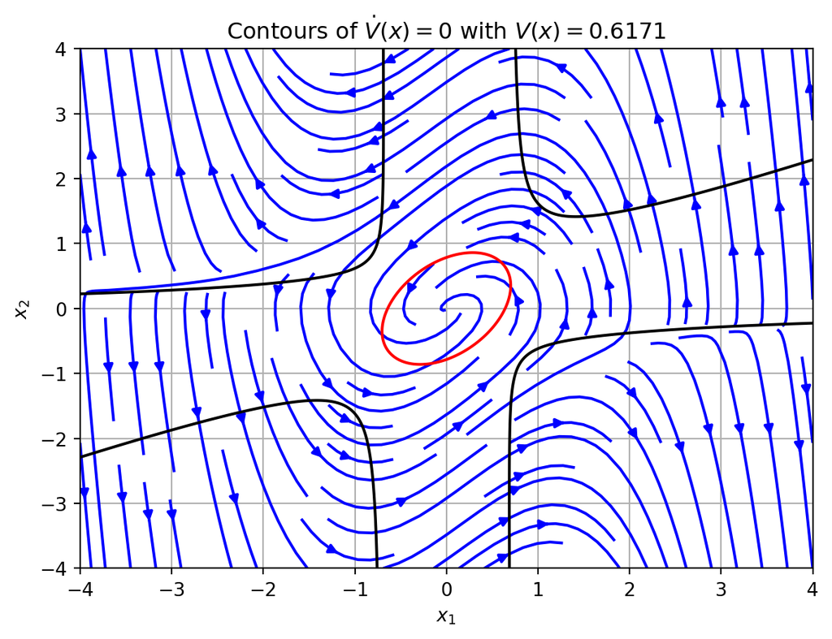

```python
x = np.linspace(-4, 4, 400)
y = np.linspace(-4, 4, 400)
X, Y = np.meshgrid(x, y)
U = -Y
V = mu * (X**2 - 1) * Y +  X

# Define the function for dotV
def dotV(X, Y):
    return -(X**2 + Y**2) - (X**3 * Y - (2 * X**2 * Y**2))

def Lyap(X, Y):
    P = np.array([[1.5, -0.5], [-0.5, 1]])
    return P[0, 0] * X**2 + 2 * P[0, 1] * X * Y + P[1, 1] * Y**2

# # Calculate dotV values
dotV_values = dotV(X, Y)
Lyap_values = Lyap(X, Y)

# Plot the contours where dotV = 0
plt.streamplot(X, Y, U, V, color='b')
plt.contour(X, Y, dotV_values, levels=[0], colors='k')
plt.contour(X, Y, Lyap_values, levels=[0.6171], colors='r')
plt.xlabel(r'$x_1$')
plt.ylabel(r'$x_2$')
plt.title(r'Contours of $\dot{V}(x) = 0$ with $V(x) = 0.6171$')
plt.grid()
plt.show()
```

A less conservative estimate can be obtained by plotting contours of $\dot{V}(x) = 0$ and $V(x) = c$ for increasing values of $c$ until we find the largest level set that fits into the domain $\{\dot{V}(x) < 0\}$.

```
Largest level set value: 2.307099999999995
```

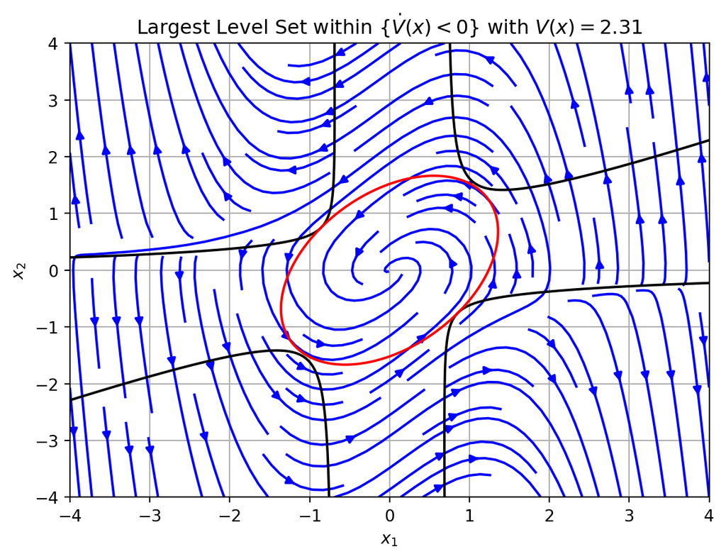

```python
def is_within_contour(level_set_value, dotV_values, Lyap_values):
    # Check if the level set is within the contour where dotV < 0
    return np.all(dotV_values[Lyap_values <= level_set_value] < 0)

# Initial level set value
level_set_value = 0.6171
increment = 0.01

# Iteratively find the largest level set value
while is_within_contour(level_set_value, dotV_values, Lyap_values):
    level_set_value += increment

# The largest level set value that is within the contour
largest_level_set_value = level_set_value - increment
print(f"Largest level set value: {largest_level_set_value}")

# Plot the result
plt.streamplot(X, Y, U, V, color='b')
plt.contour(X, Y, dotV_values, levels=[0], colors='k')
plt.contour(X, Y, Lyap_values, levels=[largest_level_set_value], colors='r')
plt.xlabel(r'$x_1$')
plt.ylabel(r'$x_2$')
plt.title(r'Largest Level Set within $\{\dot{V}(x) < 0\}$ with $V(x) = $'
    + str(round(largest_level_set_value, 2)))
plt.grid()
plt.show()
```